# Lab 3

Due: Thursday 10/03/2019 by 10 pm

Maureen McDonald and Omima Hassan

09/26/2019

## Background

The General Social Survey (GSS) has been run by NORC every other year since 1972 to keep track of current opinions across the United States. We are working with an excerpt of the dataset that covers years 1972 to 2016. The variable names along with a brief description are as follows:

| Variable | Description |
| --- | --- |
| Year | Year for this respondent |
| Age | Age of respondent |
| Sex | Sex of respondent |
| …. | ….. |

Now it’s important to understand what each column stands for. You can find a codebook with explanations for each of the variables at https://gssdataexplorer.norc.org/

Load the data set HAPPY:

```r
happy1 <- readRDS("HAPPY.rds")
names(happy1) = tolower(names(happy1))
head(happy1)
```

```
##           happy year age    sex       marital         degree       finrela
## 1 NOT TOO HAPPY 1972  23 FEMALE NEVER MARRIED       BACHELOR       AVERAGE
## 2 NOT TOO HAPPY 1972  70   MALE       MARRIED LT HIGH SCHOOL ABOVE AVERAGE
## 3  PRETTY HAPPY 1972  48 FEMALE       MARRIED    HIGH SCHOOL       AVERAGE
## 4 NOT TOO HAPPY 1972  27 FEMALE       MARRIED       BACHELOR       AVERAGE
## 5  PRETTY HAPPY 1972  61 FEMALE       MARRIED    HIGH SCHOOL ABOVE AVERAGE
## 6  PRETTY HAPPY 1972  26   MALE NEVER MARRIED    HIGH SCHOOL ABOVE AVERAGE
##      health wtssall          partyid polviews
## 1      GOOD  0.4446     IND,NEAR DEM      IAP
## 2      FAIR  0.8893 NOT STR DEMOCRAT      IAP
## 3 EXCELLENT  0.8893      INDEPENDENT      IAP
## 4      GOOD  0.8893 NOT STR DEMOCRAT      IAP
## 5      GOOD  0.8893  STRONG DEMOCRAT      IAP
## 6      GOOD  0.4446     IND,NEAR DEM      IAP
```

## Data Cleaning

Initial exploration revealed that some data processing was needed before we could proceed with further visualization. All missing values were encoded with ‘NA’ as follows:

```r
views_IAP= which(happy1$polviews == "IAP")
happy1$polviews[views_IAP]= "NA"

views_DK = which(happy1$polviews== "DK")
happy1$polviews[views_DK]= "NA"

views_NA = which(happy1$polviews== "NA")
happy1$polviews[views_NA]= "NA"

degree_Dk = which(happy1$degree== "DK")
happy1$degree[degree_Dk]= "NA"

degree_NA = which(happy1$degree== "NA")
happy1$degree[degree_NA]= "NA"

finance_IAP= which(happy1$finrela== "IAP")
happy1$finrela[finance_IAP]= "NA"

finance_DK= which(happy1$finrela== "DK")
happy1$finrela[finance_DK]= "NA"

finance_NA= which(happy1$finrela== "NA")
happy1$finrela[finance_NA]= "NA"

age_DK = which(happy1$age== "DK")
happy1$age[age_DK]= "NA"

health_DK= which(happy1$health== "DK")
happy1$health[health_DK]= "NA"

health_IAP= which(happy1$health== "IAP")
happy1$health[health_IAP]= "NA"

health_NA= which(happy1$health== "NA")
happy1$health[health_NA]= "NA"

party_DK= which(happy1$partyid== "DK")
happy1$partyid [party_DK]= "NA"

party_NA= which(happy1$partyid== "NA")
happy1$partyid [party_NA]= "NA"
```

In total, there were 30,272 number of missing values for the following 6 variables.

Variables were also cast into the correct type in order to ease data visualization. This was done by:

```r
newage= happy1$age= as.numeric(happy1$age)
happy1$age[newage]= 89
table(happy1$age)
```

```
##
##   18   19   20   21   22   23   24   25   26   27   28   29   30   31   32
##  219  834  869  983 1040 1207 1175 1332 1301 1350 1385 1284 1397 1303 1388
##   33   34   35   36   37   38   39   40   41   42   43   44   45   46   47
## 1333 1357 1341 1322 1315 1312 1178 1245 1181 1159 1199 1133 1061 1077 1073
##   48   49   50   51   52   53   54   55   56   57   58   59   60   61   62
## 1067 1089 1019 1024  998  991  968  879  968  873  934  869  894  803  839
##   63   64   65   66   67   68   69   70   71   72   73   74   75   76   77
##  805  702  780  713  773  697  648  674  590  594  532  564  481  487  449
##   78   79   80   81   82   83   84   85   86   87   88   89
##  421  367  325  320  267  253  216  185  172  143  113   71
```

```r
status = happy1 %>% group_by(marital) %>% summarize(mean_age= mean(age,na.rm=TRUE),sd_age= sd(age, na.rm=TRUE))
status
```

```
## # A tibble: 6 x 3
##   marital       mean_age sd_age
##   <chr>            <dbl>  <dbl>
## 1 DIVORCED          48.3   13.5
## 2 MARRIED           46.6   15.4
## 3 NEVER MARRIED     32.5   13.7
## 4 SEPARATED         43.4   13.9
## 5 WIDOWED           69.3   12.4
## 6 <NA>              52.9   16.4
```

```r
money = happy1 %>% group_by(finrela) %>% summarize(mean_age= mean(age,na.rm=TRUE),sd_age= sd(age, na.rm=TRUE))
money
```

```
## # A tibble: 7 x 3
##   finrela           mean_age sd_age
##   <chr>                <dbl>  <dbl>
## 1 ABOVE AVERAGE         45.6   15.8
## 2 AVERAGE               45.5   17.7
## 3 BELOW AVERAGE         46.2   18.0
## 4 FAR ABOVE AVERAGE     46.3   14.9
## 5 FAR BELOW AVERAGE     45.4   16.8
## 6 NA                    46.9   17.0
## 7 <NA>                  49.5   19.2
```

```r
party= happy1 %>% group_by(partyid) %>% summarise(mean_age= mean(age, na.rm= TRUE),sd_age= sd(age, na.rm=TRUE))
party
```

```
## # A tibble: 10 x 3
##    partyid            mean_age sd_age
##    <chr>                 <dbl>  <dbl>
##  1 IND,NEAR DEM           42.5   16.6
##  2 IND,NEAR REP           43.9   16.7
##  3 INDEPENDENT            42.1   16.4
##  4 NA                     36.7   17.4
##  5 NOT STR DEMOCRAT       45.1   17.0
##  6 NOT STR REPUBLICAN     45.9   17.5
##  7 OTHER PARTY            43.4   16.2
##  8 STRONG DEMOCRAT        50.6   17.2
##  9 STRONG REPUBLICAN      51.1   17.8
## 10 <NA>                   48.4   17.9
```

## Data Exploration

Two variables of interest are Marriage Status and Sex. Their distributions are as follow:

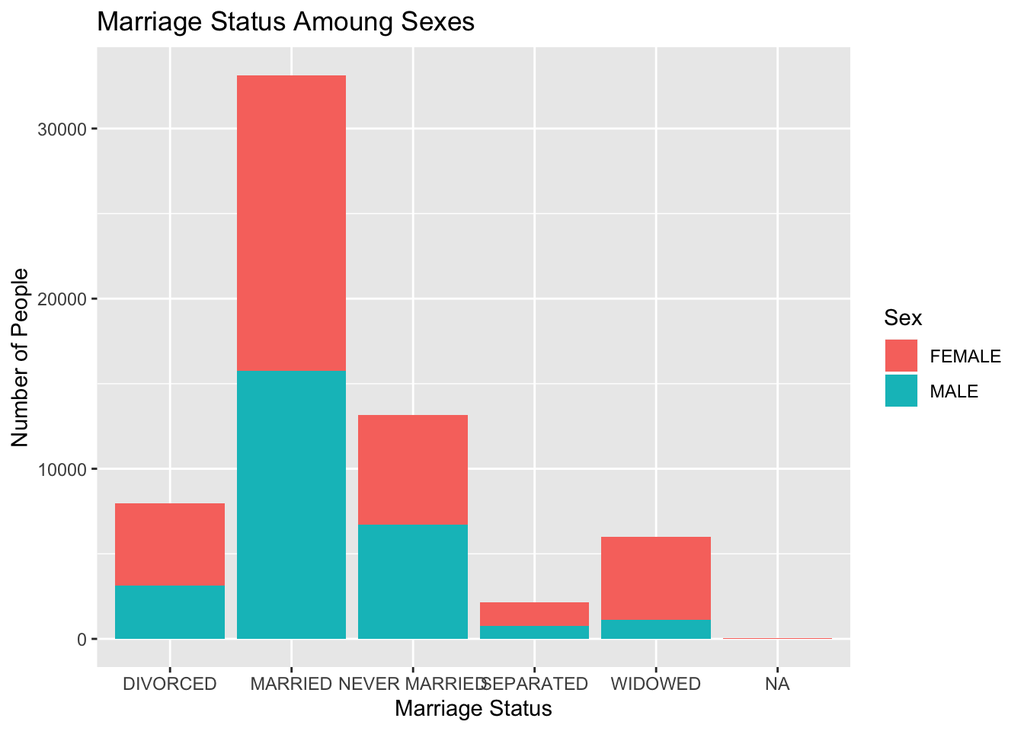

```r
ggplot(happy1,aes(marital, fill=sex)) + geom_bar()+ labs(title= "Marriage Status Amoung Sexes", x= "Marriage Status", y= "Number of People", fill= "Sex")
```

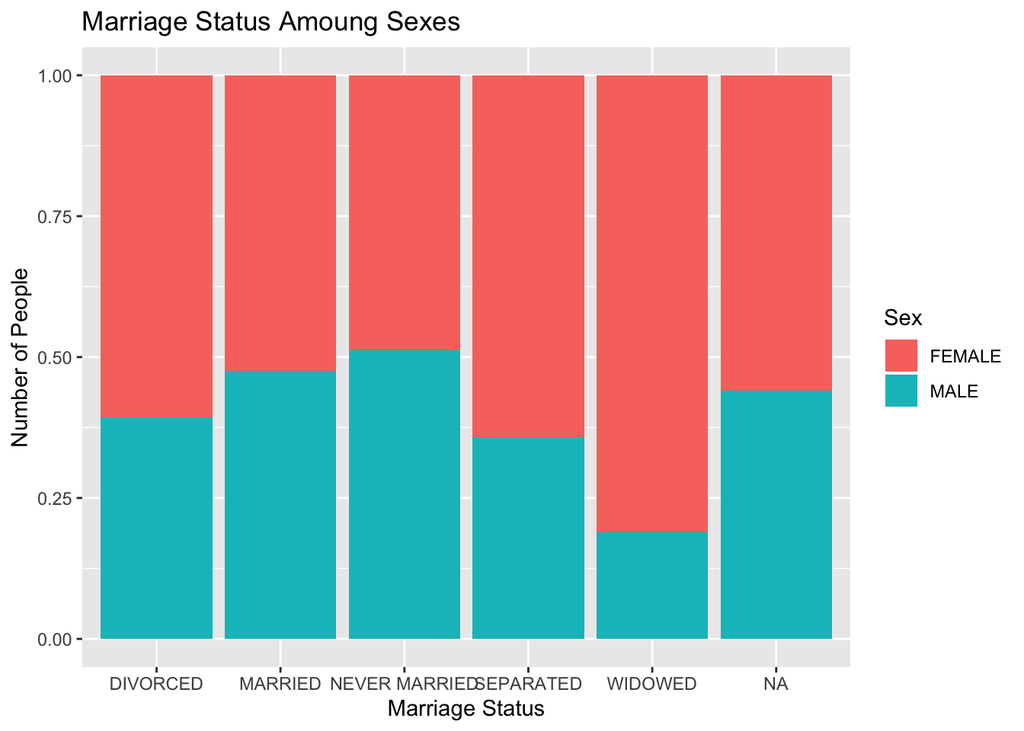

```r
ggplot(happy1,aes(marital, fill=sex)) + geom_bar(position='fill')+ labs(title= "Marriage Status Amoung Sexes", x= "Marriage Status", y= "Number of People", fill= "Sex")
```

Two variables of interest are Happiness and Marriage Status. Their distributions are as follow:

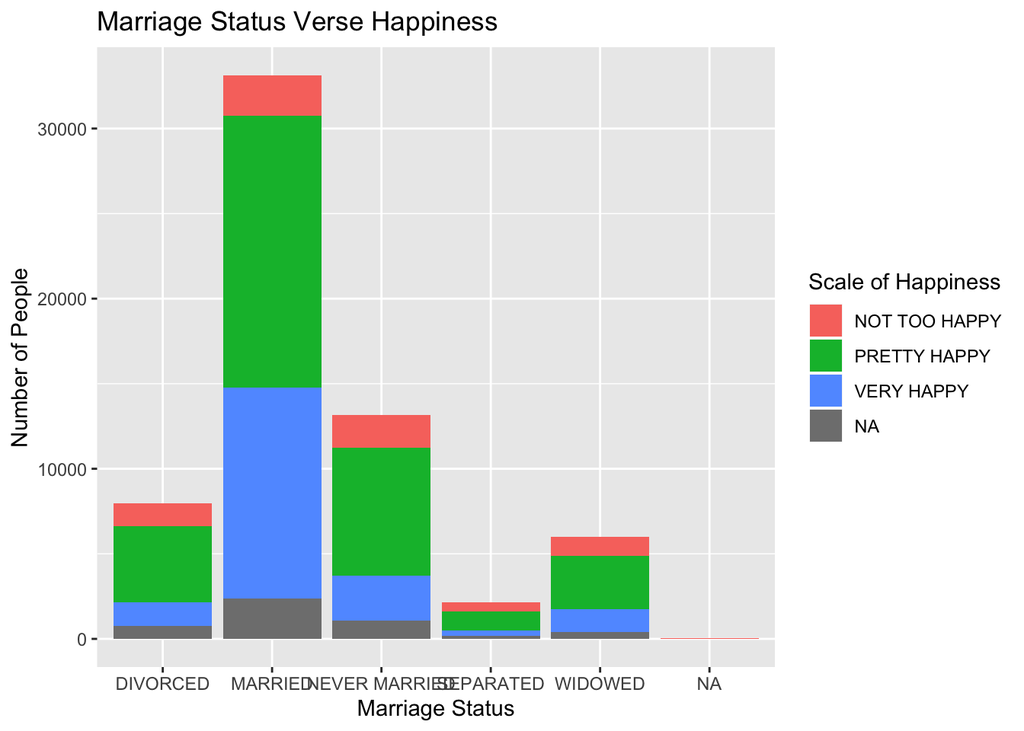

```r
ggplot(happy1,aes(marital, fill= happy)) + geom_bar()+ labs(title= "Marriage Status Verse Happiness", x= "Marriage Status", y= "Number of People", fill= "Scale of Happiness")
```

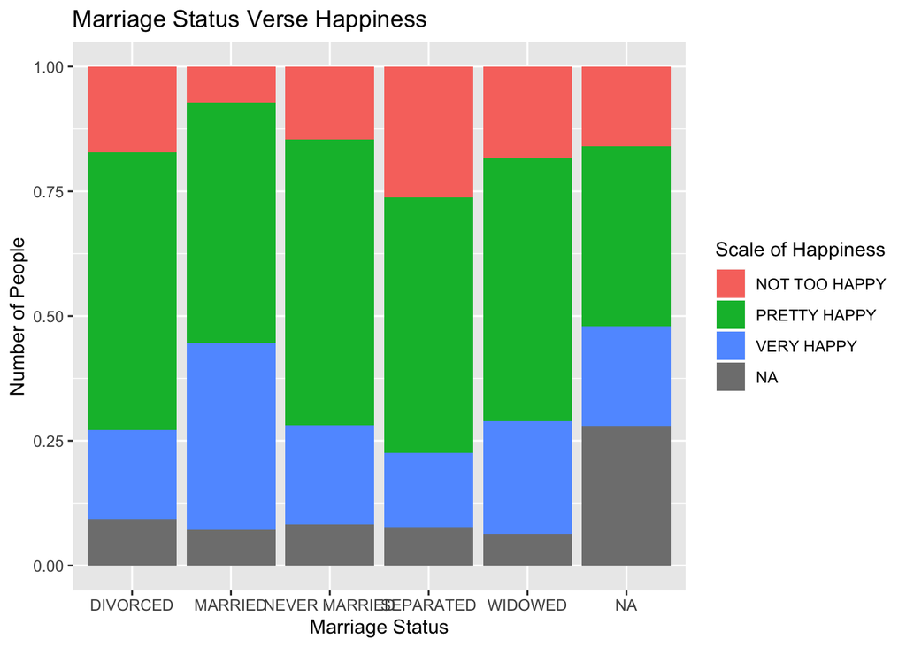

```r
ggplot(happy1,aes(marital, fill= happy)) + geom_bar(position='fill')+ labs(title= "Marriage Status Verse Happiness", x= "Marriage Status", y= "Number of People", fill= "Scale of Happiness")
```

The distribution for Marriage Status is determinded by Happiness, suggesting that in most categories the proportions of pretty happy are about the same between the marriage statuses. People who are married, however, have higher proportions of very happy and lower of not too happy. People who are seperated have higher proportions of not too happy

Two variables of interest are Age and Marriage Status. Their distributions are as follow:

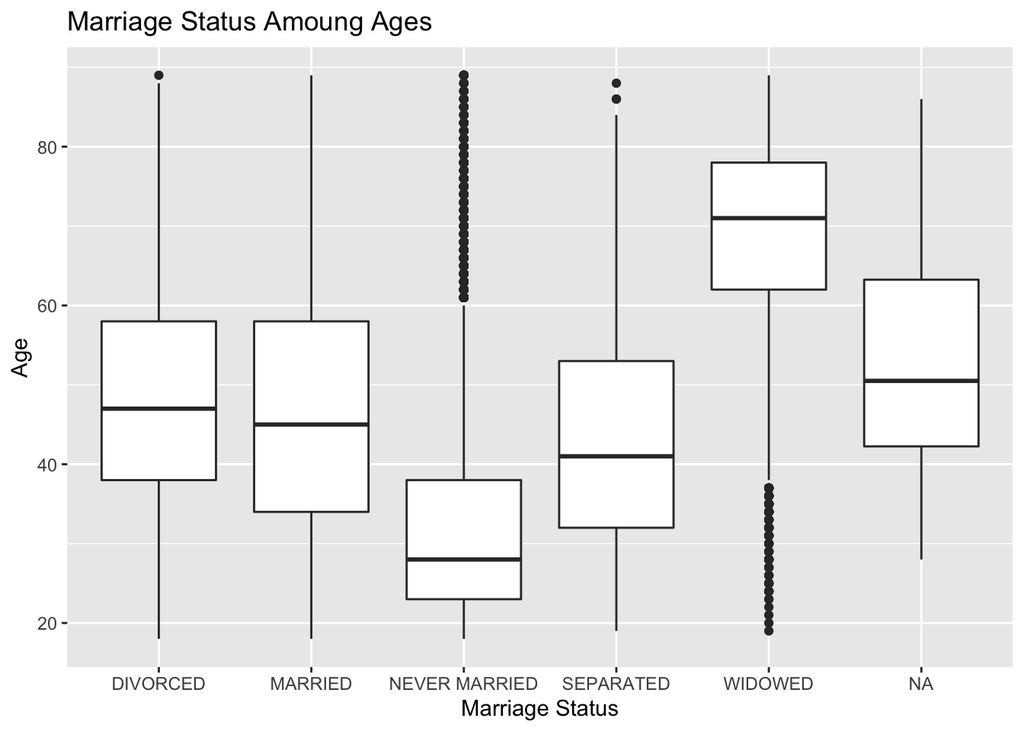

```r
ggplot(happy1,aes(marital, age)) + geom_boxplot()+ labs(title= "Marriage Status Amoung Ages", x= "Marriage Status", y= "Age")
```

The distribution for Marriage Status is determinded by age, suggesting that in most categories except for those who are widowed and never married, the proportions are about the same between the ages. Widowed, however, are more prone to being older, over 60 with the median being above 70. While people who have never been married are prone to being younger, under 40 with the median being under 30.